# PS1_Markdown_Trevisani

José Maria de Mattamouros Resende Fonseca de Oliveira (22-602-783)

Linda Fiorina Odermatt (17-946-310)

Elena Trevisani (22-620-603)

Vasily Zhuravlev (18-502-401)

2022-11-28

## Exercise 1

```r
load("insurance-all.Rdata")
nrow(data)
```

```
## [1] 1204
```

```r
ncol(data)
```

```
## [1] 7
```

observations = 1204 colums of data= 7. As we mostly collect data to examine the dependency of at least one variable on the remaining covariates, we deduce the covariates to be = 6.

## Exercise 2

```r
library(dplyr)
data %>% count(children)
```

```
##   children   n
## 1        0 519
## 2        1 296
## 3        2 215
## 4        3 138
## 5        4  22
## 6        5  14
```

```r
max(data$children)
```

```
## [1] 5
```

However, if the question adresses the highest number of children per single household who is covered by health insurance we find to folowing answer: the highest n. of children is 5 per 14 households

## Exercise 3

```r
a=levels(data$region)
b=length(a)
s.m=c()
for (i in 1:b){
  c=length(which(data$region==a[i]&data$smoker=="yes"))/length(which(data$region==a[i]))

  sss=paste("The share of smokers in", a[i],"is",as.character(c))

  print(sss)
  s.m=c(s.m, c)
}
```

```
## [1] "The share of smokers in northeast is 0.211805555555556"
## [1] "The share of smokers in northwest is 0.168965517241379"
## [1] "The share of smokers in southeast is 0.241071428571429"
## [1] "The share of smokers in southwest is 0.182758620689655"
```

```r
names(s.m)=a

names(s.m)[s.m==min(s.m)]
```

```
## [1] "northwest"
```

Alternative with matrix table

```r
cond_matrix = matrix(NA, nrow=length(levels(data$smoker)), ncol=length(levels(data$region)))
```

cond_matrix is indeed empty and full of NA

```r
a=levels(data$region)
region_matrix=matrix(a,ncol=length(a))
region_matrix
```

```
##      [,1]        [,2]        [,3]        [,4]
## [1,] "northeast" "northwest" "southeast" "southwest"
```

```r
colnames(cond_matrix)=region_matrix
rownames(cond_matrix)=levels(data$smoker)

for (a in c(1:4)) {
  cond_matrix[1,a] <- sum(data$smoker=="no" & data$region==region_matrix[,a])/sum(data$region==region_matrix[,a])
  cond_matrix[2,a] <- sum(data$smoker=="yes" & data$region==region_matrix[,a])/sum(data$region==region_matrix[,a])

}
print(cond_matrix)
```

```
##     northeast northwest southeast southwest
## no  0.7881944 0.8310345 0.7589286 0.8172414
## yes 0.2118056 0.1689655 0.2410714 0.1827586
```

Proceed with a for loop, print(cond_matrix) is the matrix has the full answer summed in a table for each region

```r
min(cond_matrix[2,])
```

```
## [1] 0.1689655
```

is the region with the lowest share of smokers: northwest, the share is 0.1689655

## Exercise 4

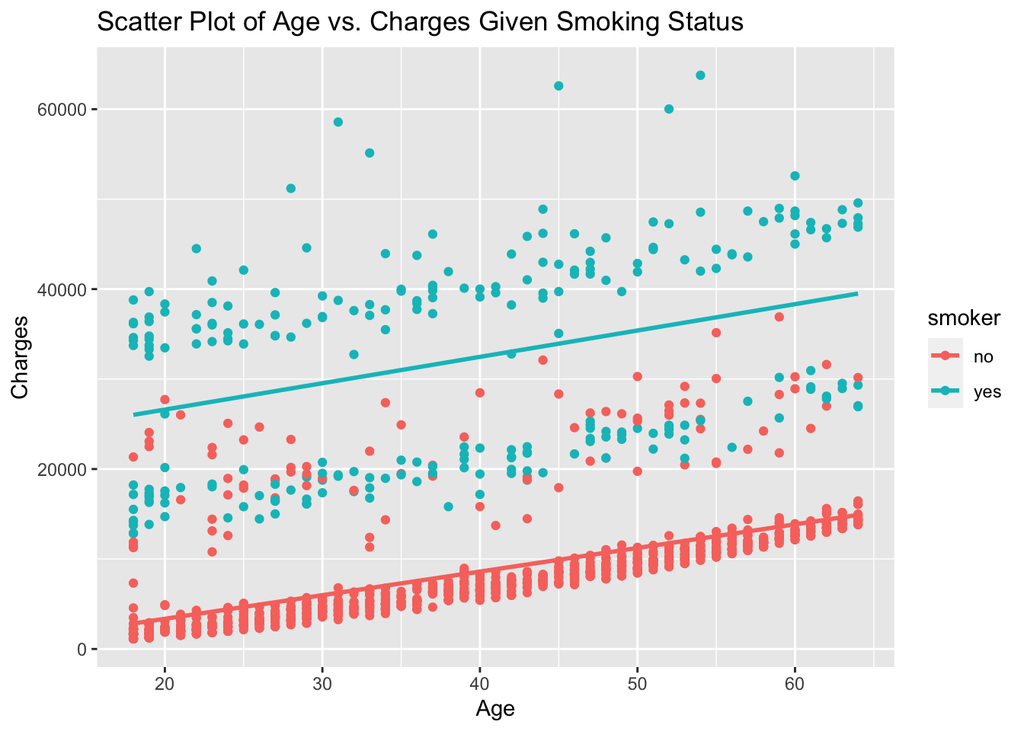

```r
library(ggplot2)
ggplot(data, aes(x=age, y=charges, color=smoker)) +
  geom_point(na.rm=TRUE) +
  ggtitle("Scatter Plot of Age vs. Charges Given Smoking Status") + ylab("Charges") + xlab("Age") +
  geom_smooth(method = "lm", se = FALSE)
```

From the scatter plot we find the following patterns: We see that the charges for medical bills for smokers are on average much higher than the charges for people who don’t smoke. Having the age variable on the x-axis, we oberve that the charges correlate with age. As people age, they should expect their medical charges to increase.

## Exercise 5

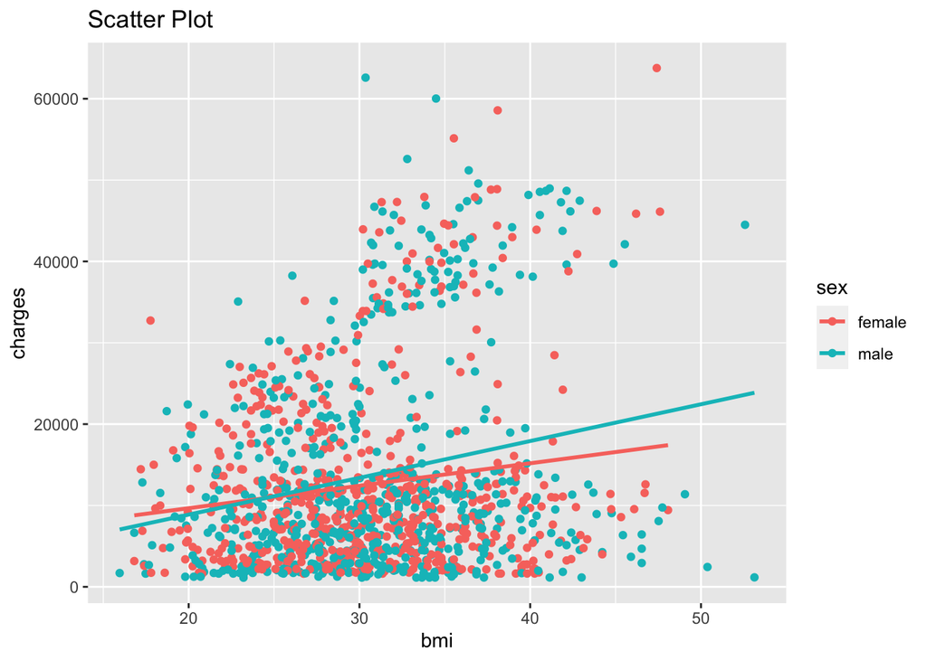

```r
scatter_plot <- function(any_data, x.variable, y.variable, color.variable){

      if ( class(any_data)!="data.frame" ) {
    stop("any_data not of data.frame type")
  }

    ggplot(any_data, aes(x=get(x.variable), y=get(y.variable), color=get(color.variable)))+
    geom_point(na.rm=TRUE)+ ggtitle("Scatter Plot") +
    labs(x=x.variable,y=y.variable,colour=color.variable)+
    geom_smooth(method = "lm", se = FALSE)
}
scatter_plot(data,"bmi","charges","sex")
```

We observe that as bmi increases, the variance of charges also increases, therefore the data has heteroskedasticity implied in it. Moreover, we observe in general a weakly positive correlation between the bmi and charges, more so for males.A possible explanation could be that males are more likely to afford medical costs. A possible way to improve the analysis, is by also accounting for the wage differences of between individuals.

## Exercise 6

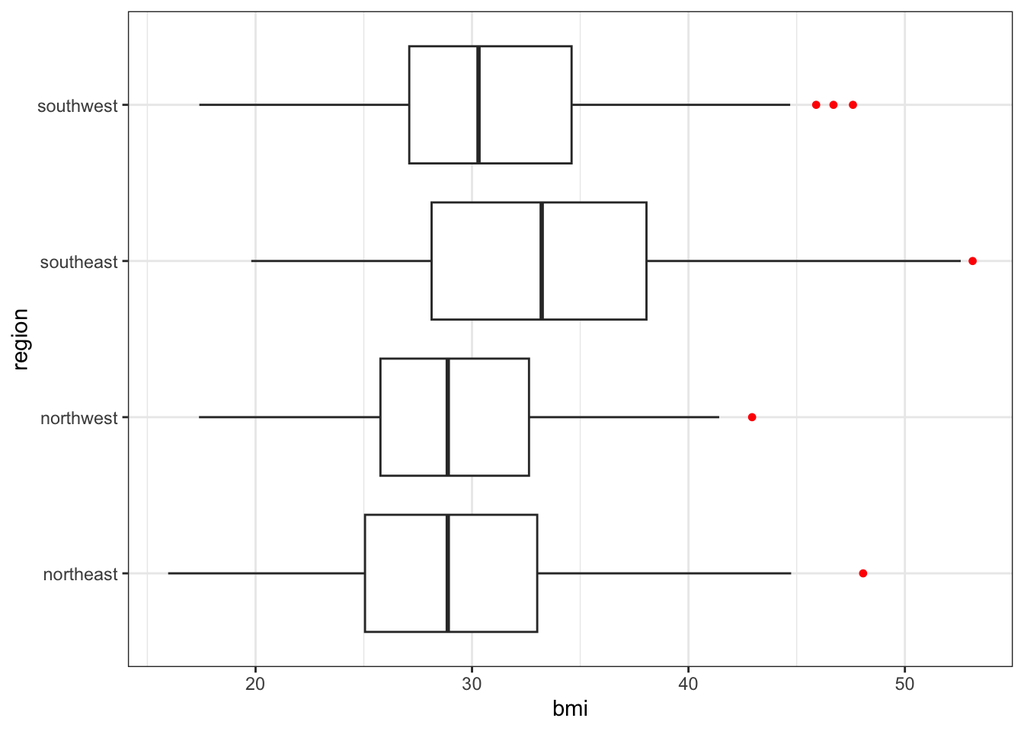

```r
bmi_boxplot <- function(data_inp, split_var){

     if ( class(data_inp)!="data.frame" ) {
    stop("any_data not of data.frame type")
  }

  ggplot(data=data_inp,aes(x =data_inp$bmi, y=get(split_var)))+
    geom_boxplot(outlier.colour="red", outlier.shape=20, outlier.size=2)+
    labs(x="bmi", y=split_var)+theme_bw()

}
bmi_boxplot(data,"region")
```